# Time Series analysis

### Data

Use ARIMA and ETS modeling techniques to forecast future trends. Compare the forecasts of each model.

```r
library(quantmod)

srln<-getSymbols("SRLN", auto.assign = FALSE, warnings=FALSE)
```

Convert the adjusted price (which accounts for dividends and splits) to a “ts” time series object.

```r
data<-ts(srln$SRLN.Adjusted)
```

### Models

Our first model is an ARIMA model using default settings.

By default, model selection involves stepwise model selection (faster than scanning all models). Approximation via conditional sum of squares is used in model selection.

```r
library(forecast)
srln_arima<-auto.arima(data)
```

The second model is an ARIMA model chosen by scanning all model parameters

```r
srln_arima2<-auto.arima(data, stepwise = F, approximation=F)
```

The third model is an Exponential Smoothing model chosen automatically

```r
srln_ets <- ets(data)
```

### Forecast

Forecast data for next 100 days

```r
f_arima1 <-forecast(srln_arima,h=100)
f_arima2 <- forecast(srln_arima2, h=100)
f_ets<-forecast(srln_ets, h=100)
```

### Model Comparison

Show plot of the forecasted averages for each model. In this case the projected mean of both ARIMA models are very close. The ETS projection is much flatter by comparison.

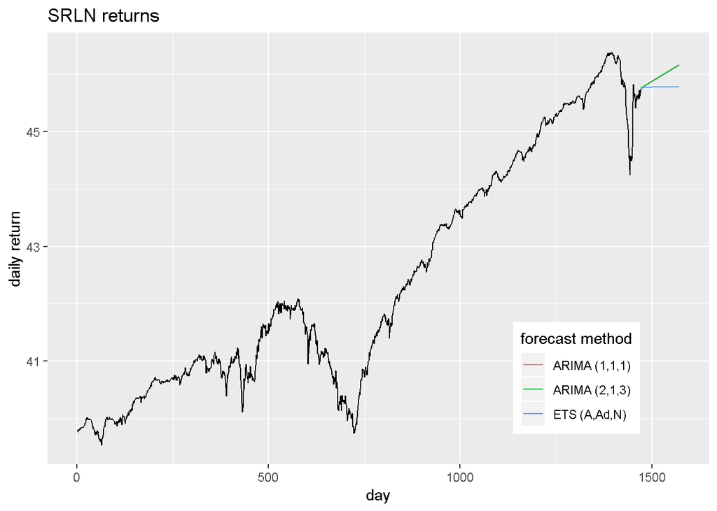

```r
library(ggplot2)
autoplot(data) + forecast::autolayer(f_arima1$mean, series="ARIMA (1,1,1)")+ forecast::autolayer(f_arima2$mean, series="ARIMA (2,1,3)")+ forecast::autolayer(f_ets$mean, series="ETS (A,Ad,N)")+ xlab("day")+ ylab("daily return") + guides(color=guide_legend(title="forecast method"))+ theme(legend.position = c(0.8,0.2)) + ggtitle("SRLN returns")
```

### Confidence Intervals

The 80 and 95 percent Confidence intervals for the ARIMA model are upward sloping along the trend.

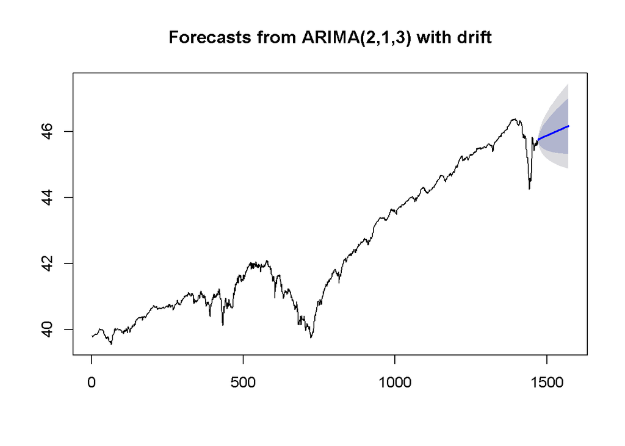

```r
plot(f_arima2)
```

Here we can see the 80 and 95 percent confidence intervals for the Exponential smoothing model are flatter.

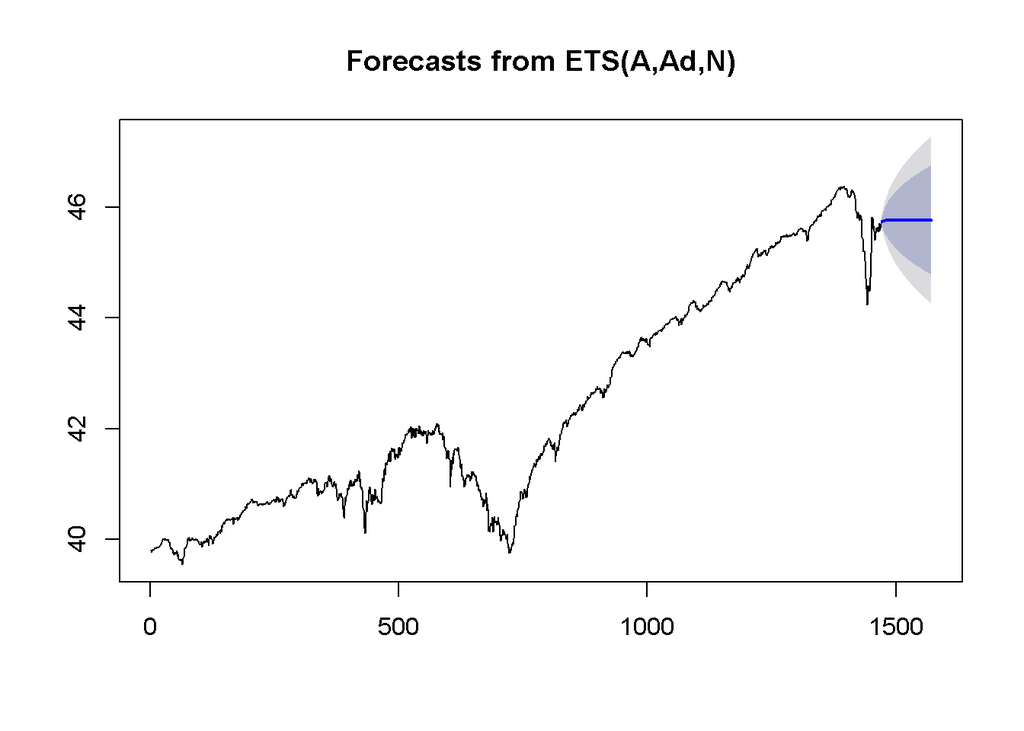

```r
plot(f_ets)
```